# Ford GoBike Dataset Explanation

## by Mohammed Ezzat Yassin

## Investigation Overview

In this investigation of the Ford GoBike System, I wanted to look at the riding habit/pattern for the numer of trips and trips duration with respect to time and rider gender, type, and age.

## Dataset Overview

The dataset includes information about individual rides made in a bike-sharing system covering the greater San Francisco Bay area in feb, 2019.

## First, lets explore the bike rides by gender:

#### Although, men are represents 75% of the reiders

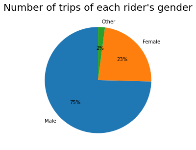

#### , and consequently have larger numer of trips than women, but women have average trips distance and duration larger than men especially at weekends.

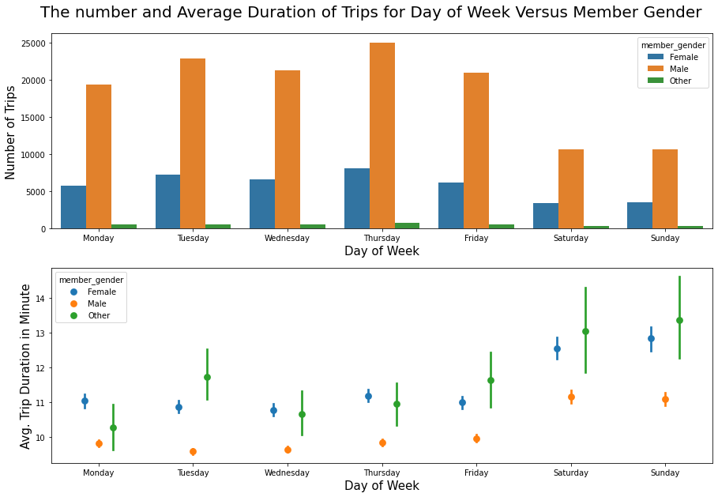

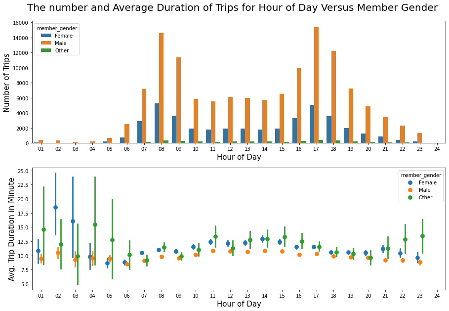

#### This pattern shows that women doesn't prefer using the service for work transportation than Exercising out of work times, this may be beacause of the physical exertion of bike riding or women work dressing style which doesn't convenient with bike pedaling. So that, ebikes those taking some of the effort out of pedaling will be an apporiate solution to increase the number of women riders.

## Next up, lets explore the bike rides at weekend and work days:

#### The number of trips show that the work days obsesse the most trips beacasue that the service is mainly used for work transportation especially at the ruch hours of going to (07, 08, 09) and from work (16, 17, 18).

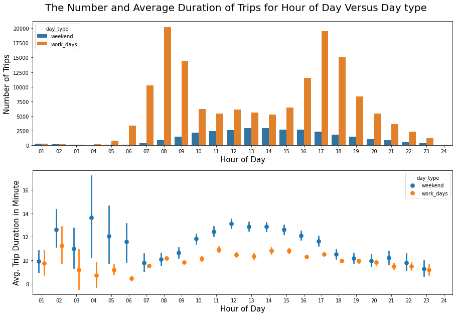

#### While, the duration of trips show that the trips at weekends have a much higher average durations for the younger and older riders.

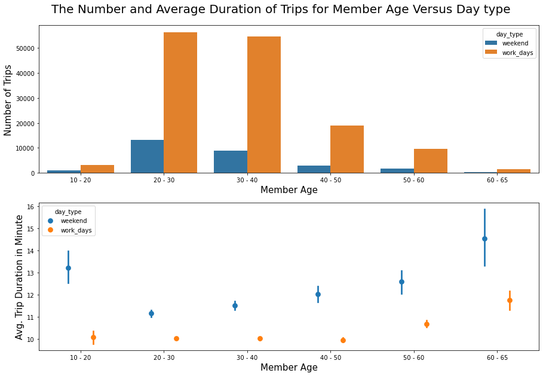

#### Also, the customers have constant usage of the service along the week days which reflects that at weekend at which the suscribers have a low service usage, the customers have an average duration of trips higher than the suscribers

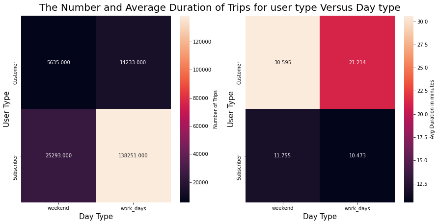

#### So that, the company should creates a special package for the weekend riding which will encourage much people whose prefer using the bikes as Exercising rather than work transportation to use the services.